# Exploratory Data Analysis of Chronic Disease Indicators

Maggie Kohn

## Comparable Topics & Questions

To safely compare data across different indicators, we need to ensure that the units and types of measurements are consistent. The table below summarizes the number of unique topics and questions available for each combination of `DataValueUnit` and `DataValueType`.

|  | DataValueUnit | DataValueType | n_questions | n_topics |
| --- | --- | --- | --- | --- |
| 1 | % | Crude Prevalence | 72 | 17 |
| 2 | % | Age-adjusted Prevalence | 46 | 16 |
| 3 | Number | Number | 12 | 5 |
| 4 | cases per 100,000 | Age-adjusted Rate | 9 | 5 |
| 5 | cases per 100,000 | Crude Rate | 9 | 5 |
| 6 | Number | Age-adjusted Mean | 3 | 2 |
| 7 | Number | Crude Mean | 3 | 2 |
| 8 | cases per 1,000 | Age-adjusted Rate | 3 | 2 |
| 9 | cases per 1,000 | Crude Rate | 3 | 2 |
| 10 | % | Proportion | 1 | 1 |

[output cut: 6 more lines]

#### Let’s take a closer look at the most common combination: `%` and `Crude Prevalence`. The table below lists all the unique questions available for this combination.

The majority of these are **risk factors** for chronic diseases.

|  | Topic | Question |
| --- | --- | --- |
| 1 | Alcohol | Alcohol use among high school students |
| 2 | Alcohol | Binge drinking prevalence among high school students |
| 3 | Alcohol | Binge drinking prevalence among adults |
| 4 | Arthritis | Physical inactivity among adults with arthritis |
| 5 | Arthritis | Severe joint pain among adults with arthritis |
| 6 | Arthritis | Have taken an educational class to learn how to manage arthritis symptoms among adults with arthritis |
| 7 | Arthritis | Received health care provider counseling for physical activity among adults with arthritis |
| 8 | Arthritis | Work limitation due to arthritis among adults aged 18-64 years with arthritis |
| 9 | Arthritis | Activity limitation due to arthritis among adults with arthritis |
| 10 | Arthritis | Arthritis among adults |

[output cut: 62 more lines]

##### The following visualizations use two questions from this group:

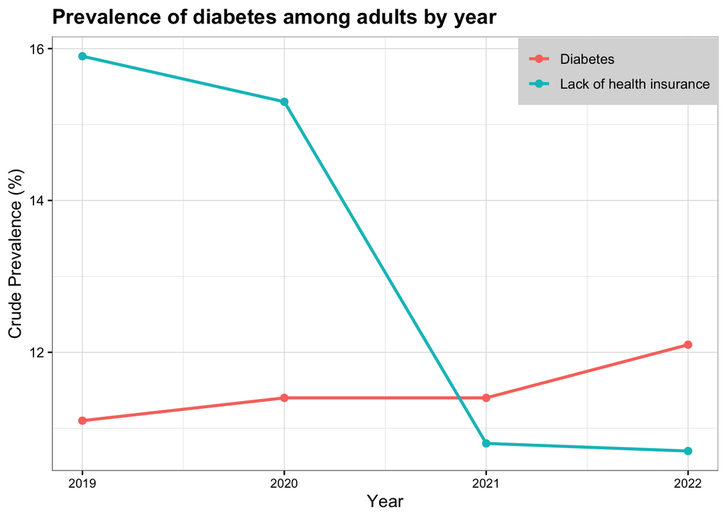

Significant missingness (17 states in 2022) in the lack of health insurance data for the year of 2022 may also be affecting this trend. When more data is uploaded to the CDI dataset this may impact the trend. Based on the states that have uploaded data for both indicators it appears that as more people have access to health insurance the prevalence of diabetes increases suggesting that diagnoses are under counted when people do not have access to healthcare.

#### Let’s take a closer look at the next most common combination: `%` and `Age-adjusted Prevalence`. The table below lists all the unique questions available for this combination.

The majority of these are risk factors for chronic diseases.

|  | Topic | Question |
| --- | --- | --- |
| 1 | Alcohol | Binge drinking prevalence among adults |
| 2 | Arthritis | Physical inactivity among adults with arthritis |
| 3 | Arthritis | Severe joint pain among adults with arthritis |
| 4 | Arthritis | Received health care provider counseling for physical activity among adults with arthritis |
| 5 | Arthritis | Activity limitation due to arthritis among adults with arthritis |
| 6 | Arthritis | Work limitation due to arthritis among adults aged 18-64 years with arthritis |
| 7 | Arthritis | Have taken an educational class to learn how to manage arthritis symptoms among adults with arthritis |
| 8 | Arthritis | Arthritis among adults |
| 9 | Asthma | Current asthma among adults |
| 10 | Cancer | Mammography use among women aged 50-74 years |

[output cut: 36 more lines]

##### The following visualizations use two questions from this group:

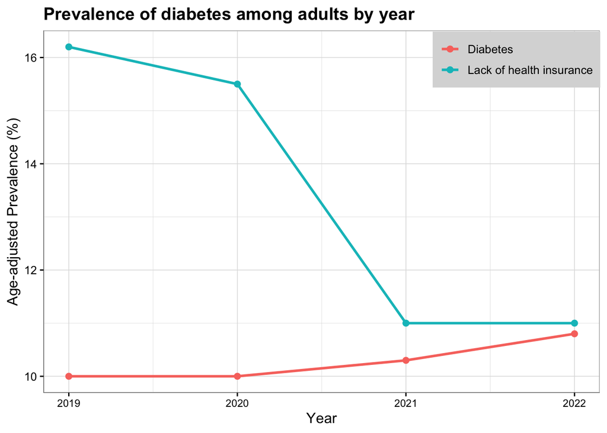

#### Let’s take a closer look at the next most common combination: `Number` and `Number`. The table below lists all the unique questions available for this combination.

|  | Topic | Question |
| --- | --- | --- |
| 1 | Alcohol | Chronic liver disease mortality among all people, underlying cause |
| 2 | Asthma | Asthma mortality among all people, underlying cause |
| 3 | Cardiovascular Disease | Diseases of the heart mortality among all people, underlying cause |
| 4 | Cardiovascular Disease | Cerebrovascular disease (stroke) mortality among all people, underlying cause |
| 5 | Cardiovascular Disease | Coronary heart disease mortality among all people, underlying cause |
| 6 | Cardiovascular Disease | Hospitalization for heart failure as principal diagnosis, Medicare-beneficiaries aged 65 years and older |
| 7 | Chronic Obstructive Pulmonary Disease | Hospitalization for chronic obstructive pulmonary disease as any diagnosis, Medicare-beneficiaries aged 65 years and older |
| 8 | Chronic Obstructive Pulmonary Disease | Hospitalization for chronic obstructive pulmonary disease as principal diagnosis, Medicare-beneficiaries aged 65 years and older |
| 9 | Chronic Obstructive Pulmonary Disease | Chronic obstructive pulmonary disease mortality among adults aged 45 years and older, underlying cause |
| 10 | Chronic Obstructive Pulmonary Disease | Chronic obstructive pulmonary disease mortality among adults aged 45 years and older, underlying or contributing cause |

[output cut: 2 more lines]

The majority of these are counts of chronic disease cases and mortality rates.

#### Let’s take a closer look at the next most common combination: `cases per 100,000` and `Age-adjusted Rate`. The table below lists all the unique questions available for this combination.

|  | Topic | Question |
| --- | --- | --- |
| 1 | Alcohol | Chronic liver disease mortality among all people, underlying cause |
| 2 | Asthma | Asthma mortality among all people, underlying cause |
| 3 | Cardiovascular Disease | Diseases of the heart mortality among all people, underlying cause |
| 4 | Cardiovascular Disease | Coronary heart disease mortality among all people, underlying cause |
| 5 | Cardiovascular Disease | Cerebrovascular disease (stroke) mortality among all people, underlying cause |
| 6 | Chronic Obstructive Pulmonary Disease | Chronic obstructive pulmonary disease mortality among adults aged 45 years and older, underlying or contributing cause |
| 7 | Chronic Obstructive Pulmonary Disease | Chronic obstructive pulmonary disease mortality among adults aged 45 years and older, underlying cause |
| 8 | Diabetes | Diabetes mortality among all people, underlying or contributing cause |
| 9 | Diabetes | Diabetic ketoacidosis mortality among all people, underlying or contributing cause |

The majority of these are counts of chronic disease cases and mortality rates.

#### Let’s take a closer look at the next most common combination: `cases per 100,000` and `Crude Rate`. The table below lists all the unique questions available for this combination.

|  | Topic | Question |
| --- | --- | --- |
| 1 | Alcohol | Chronic liver disease mortality among all people, underlying cause |
| 2 | Asthma | Asthma mortality among all people, underlying cause |
| 3 | Cardiovascular Disease | Cerebrovascular disease (stroke) mortality among all people, underlying cause |
| 4 | Cardiovascular Disease | Diseases of the heart mortality among all people, underlying cause |
| 5 | Cardiovascular Disease | Coronary heart disease mortality among all people, underlying cause |
| 6 | Chronic Obstructive Pulmonary Disease | Chronic obstructive pulmonary disease mortality among adults aged 45 years and older, underlying cause |
| 7 | Chronic Obstructive Pulmonary Disease | Chronic obstructive pulmonary disease mortality among adults aged 45 years and older, underlying or contributing cause |
| 8 | Diabetes | Diabetic ketoacidosis mortality among all people, underlying or contributing cause |
| 9 | Diabetes | Diabetes mortality among all people, underlying or contributing cause |

The majority of these are counts of chronic disease cases and mortality rates.

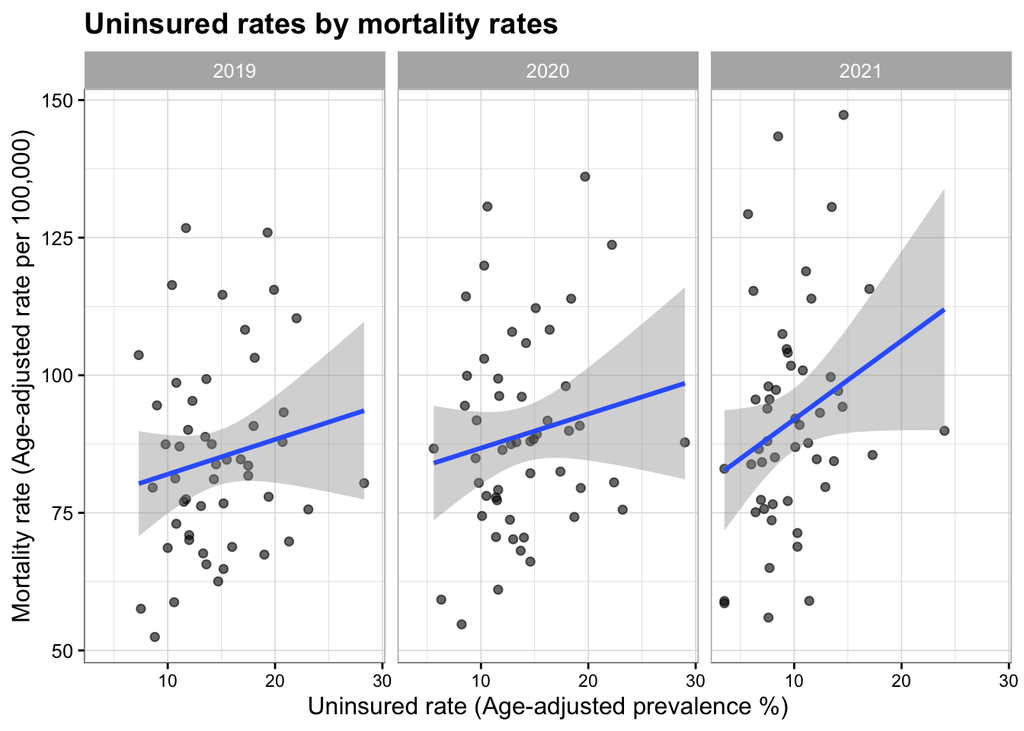

## General Questions

### Which state has the highest mortality rate?

```r
clean_cdi |>
  filter(
    str_detect(Question, "mortality"),
    str_detect(DataValueType, "Age-adjusted"),
    Stratification1 == "Overall",
    str_detect(Year, "^\\d{4}$")
  ) |>
  arrange(desc(DataValue)) |>
  select(Year, LocationAbbr, DataValue) |>
  datatable()
```

|  | Year | LocationAbbr | DataValue |
| --- | --- | --- | --- |
| 1 | 2021 | OK | 495.8 |
| 2 | 2020 | OK | 455 |
| 3 | 2021 | KY | 440.6 |
| 4 | 2019 | OK | 415.8 |
| 5 | 2021 | WV | 415.6 |
| 6 | 2020 | KY | 404.4 |
| 7 | 2019 | KY | 393 |
| 8 | 2020 | WV | 382.4 |
| 9 | 2021 | WY | 367.7 |
| 10 | 2021 | MS | 367 |

[output cut: 1394 more lines]

### Which state has the highest uninsured rate?

```r
clean_cdi |>
  filter(
    str_detect(Question, "Lack of health insurance among adults"),
    str_detect(DataValueType, "Age-adjusted"),
    Stratification1 == "Overall",
    str_detect(Year, "^\\d{4}$")
  ) |>
  arrange(desc(DataValue)) |>
  select(Year, LocationAbbr, DataValue) |>
  datatable()
```

|  | Year | LocationAbbr | DataValue |
| --- | --- | --- | --- |
| 1 | 2020 | TX | 29 |
| 2 | 2019 | TX | 28.3 |
| 3 | 2022 | VI | 24.3 |
| 4 | 2021 | TX | 24 |
| 5 | 2020 | FL | 23.2 |
| 6 | 2019 | GA | 23.1 |
| 7 | 2020 | GA | 22.4 |
| 8 | 2019 | GU | 22.3 |
| 9 | 2020 | GU | 22.3 |
| 10 | 2020 | MS | 22.2 |

[output cut: 210 more lines]

### Which chronic disease has the most missing data?

```r
topic_of_interest <- c(
  "Chronic Obstructive Pulmonary Disease",
  "Cardiovascular Disease",
  "Diabetes"
)



clean_cdi |>
  filter(
    Topic %in% topic_of_interest,
    str_detect(Question, "mortality"),
    str_detect(DataValueType, "Age-adjusted"),
    Stratification1 == "Overall",
    !(is.na(DataValueFootnote))
  ) |>
  select(
    LocationAbbr,
    Topic,
    Year
  ) |>
  datatable()
```

|  | LocationAbbr | Topic | Year |
| --- | --- | --- | --- |
| 1 | AK | Diabetes | 2019 |
| 2 | HI | Diabetes | 2019 |
| 3 | DC | Diabetes | 2019 |
| 4 | DE | Diabetes | 2019 |
| 5 | ND | Diabetes | 2019 |
| 6 | RI | Diabetes | 2019 |
| 7 | SD | Diabetes | 2019 |
| 8 | VT | Diabetes | 2019 |
| 9 | WY | Diabetes | 2019 |
| 10 | AK | Diabetes | 2020 |

[output cut: 7 more lines]